# MScA, Linear and Nonlinear Models (31010)

Yuri Balasanov, © iLykei 2016

# Week 6 project: Estimation of intensity of non-homogeneous Poisson process

Estimate time-dependent intensity of a non-homogeneous Poisson process given in the file `EventsRecord.csv`.

Read the data.

```r
eventTimes<-read.csv(file=paste(dataPath,"EventsRecord.csv",sep="/"))[,1]
head(eventTimes)
```

```
## [1]  4 11 12 20 21 38
```

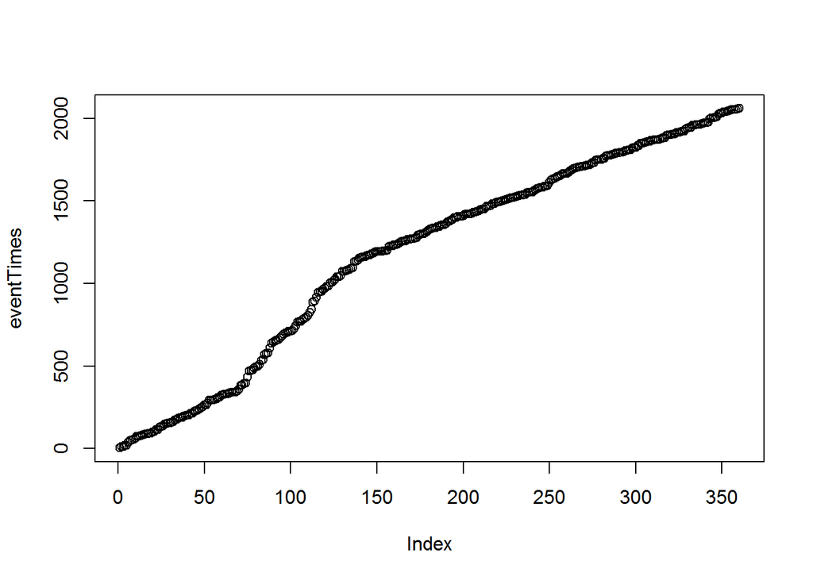

```r
plot(eventTimes)
```

The data contain times of events in seconds from the start of the record.  
For example, the first event in the sample period occurred 4 seconds after the start of the record; the second event occurred 11 seconds after the start of the record.

Write function `estimateIntensity<-function(times)` that estimates intensity of a Poisson process from sample of times of events and returns it.

Use the following formula for estimation of intensity:

$$\lambda = \frac{N}{t_e - t_b},$$
where $N$ is the number of events in the sample, $t_e$ is the end time of the sample period (last time stamp in the sample of event times) and $t_b$ is the begin time of the sample period (first time stamp of the sample of event times).

Intensity is measured as nmber of events per second.

(Skipped Code)

Apply the intensity estimation function to the sample with rolling window.

```r
suppressMessages(library(zoo))
estimLambda<-rollapply(eventTimes,width=30,FUN=estimateIntensity,partial=T)
head(estimLambda,20)
```

```
##  [1] 0.1927711 0.2000000 0.2045455 0.2134831 0.2105263 0.2121212 0.2018349
##  [8] 0.2072072 0.1904762 0.1953125 0.1984733 0.1862069 0.1904762 0.1946309
## [15] 0.1973684 0.2040816 0.2013423 0.1960784 0.1923077 0.2040816
```

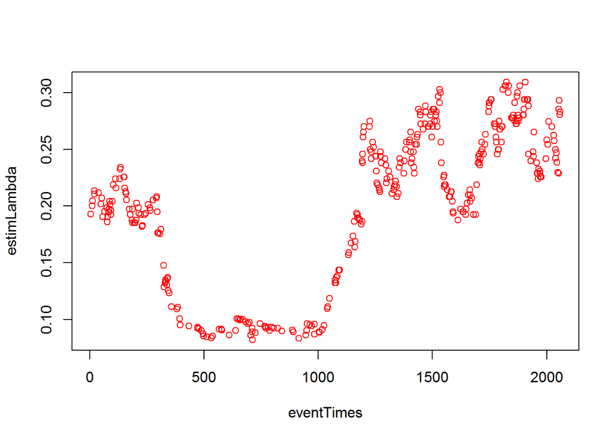

```r
plot(eventTimes,estimLambda,col="red")
```

Compare the estimated intensities with the “true” lambdas used for simulation.

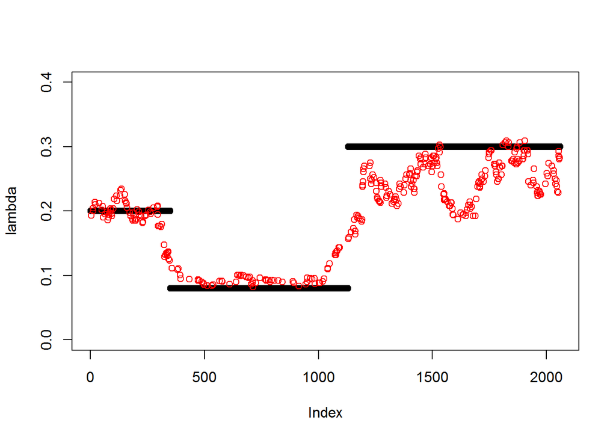